# Inference and Prediction

### Table of Contents

Prediction and inference are two-sides of the same coin. People tend to think they are working in one or the other, but techniques traditionally used for one area can help inform the other.

Since you have already seen decision trees and random forests, you can consider how these two techniques might be used to generate variables of interest for an inferential model.

We will spend time with `lime` next mod!

## Helpful Packages

```r
install.packages(c("psych", "factoextra", "FactoMineR", "penalized"))
```

# PCA

PCA takes our multidimensional data and reduces it down to fewer dimensions.

This is accomplished by using the covariance between variables (eigenvalues) and direction of axes (eigenvectors).

This strength and direction is then used to *rotate* the data and project it to a smaller space.

Just as a reminder, only use PCA when you want to reduce the number of variables.

PCA components don’t mean anything (technically).

- We will see where we can play with that a bit, though.

## Helpful Functions

For PCA, you have some choices: `princomp()` or `prcomp()`

- `princomp` is done using spectral decomposition
- `prcomp` is done using singular value decomposition

How many factors/components do you need: `psych::fa.parallel()`

## Data

```r
hospitalData <- data.table::fread("http://www.nd.edu/~sberry5/data/hospitalData.csv")

hospitalData <- as.data.frame(hospitalData)

names(hospitalData)
```

```
[1] "NFP"               "HospAge"           "TotVen"
[4] "AHAAdmissions"     "TotalOperExpense"  "NofAdjDischarge"
[7] "NofAdjPatientDays" "NofBeds"
```

## A Quick Visualization

```r
library(plotly)

plot_ly(hospitalData, x = ~HospAge, y = ~AHAAdmissions, z = ~TotalOperExpense,
        color = ~as.factor(NFP), colors = c('#BF382A', '#0C4B8E')) %>%
  add_markers()
```

[interactive chart not shown]

## And after PCA

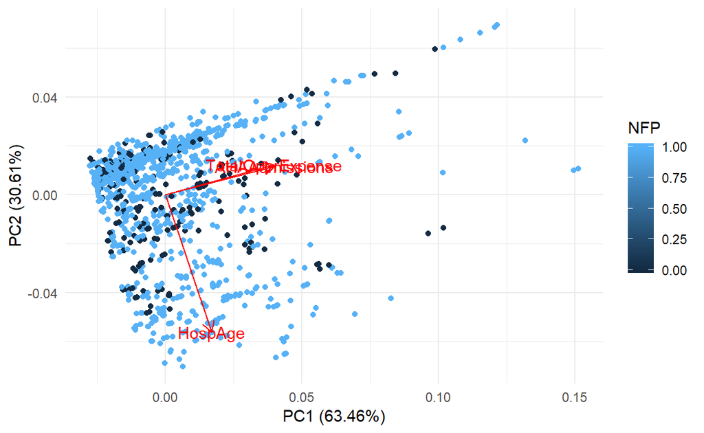

```r
library(ggplot2); library(ggfortify); library(factoextra)

keepVariables = c("HospAge", "AHAAdmissions", "TotalOperExpense")

pcaResult = prcomp(hospitalData[, keepVariables], scale. = TRUE)

autoplot(pcaResult,
         data = hospitalData, colour = "NFP",
         loadings = TRUE, loadings.label = TRUE) +
  theme_minimal()
```

## Contributions To Components

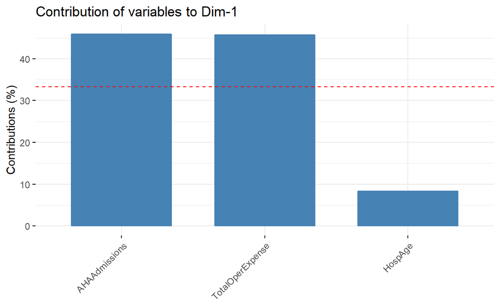

```r
fviz_contrib(pcaResult, choice = "var", axes = 1, top = 5)
```

## Contributions To Components

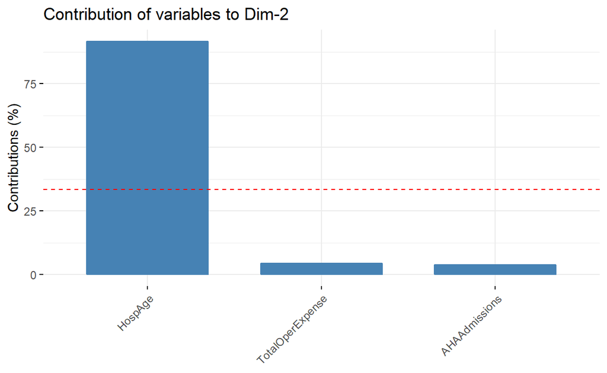

```r
fviz_contrib(pcaResult, choice = "var", axes = 2, top = 5)
```

Let’s try it with some data that we have already seen:

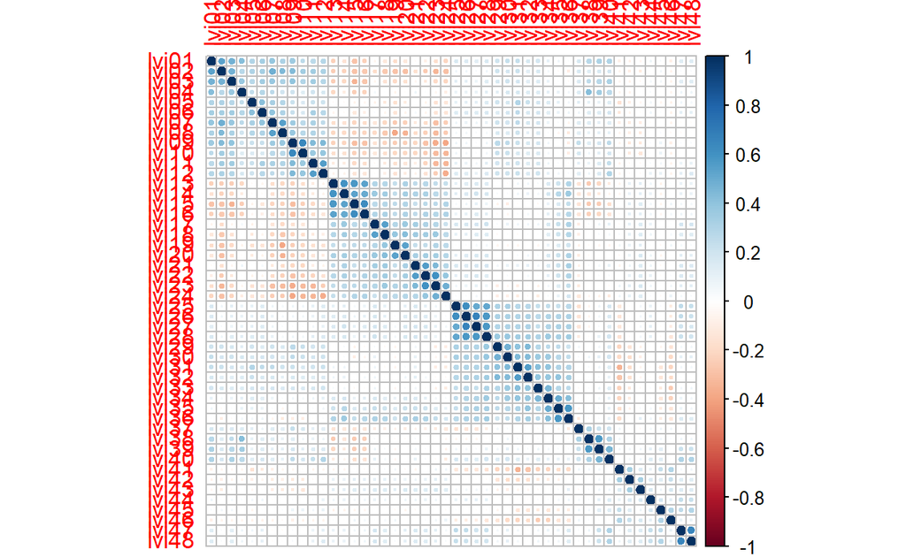

```r
library(dplyr)

load("C://Users/sberry5/Documents/teaching/courses/inf/notes/teamPerc.RData")

pcaVars <- teamPerc %>%
  filter(Rater == 3) %>%
  select(starts_with("lvi"), effect)

cor(pcaVars[, 1:48], use = "pairwise.complete.obs") %>%
  corrplot::corrplot()
```

And in a regression:

```r
mod <- lm(effect ~ ., data = pcaVars)

broom::tidy(mod)
```

```
# A tibble: 49 x 5
   term        estimate std.error statistic  p.value
   <chr>          <dbl>     <dbl>     <dbl>    <dbl>
 1 (Intercept)   8.65     0.00993    871.   0.
 2 lvi01         0.0396   0.00970      4.09 4.38e- 5
 3 lvi02        -0.0455   0.00965     -4.72 2.38e- 6
 4 lvi03        -0.0182   0.00874     -2.08 3.76e- 2
 5 lvi04         0.0109   0.00874      1.24 2.13e- 1
 6 lvi05         0.0715   0.00799      8.94 4.23e-19
 7 lvi06         0.0883   0.00902      9.79 1.37e-22
 8 lvi07        -0.0969   0.0100      -9.68 4.10e-22
 9 lvi08        -0.0578   0.00911     -6.35 2.24e-10
10 lvi09         0.0186   0.00946      1.97 4.91e- 2
# ... with 39 more rows
```

```r
broom::glance(mod)
```

```
# A tibble: 1 x 11
  r.squared adj.r.squared sigma statistic p.value    df  logLik    AIC
      <dbl>         <dbl> <dbl>     <dbl>   <dbl> <int>   <dbl>  <dbl>
1     0.329         0.327  1.05      208.       0    49 -30015. 60131.
# ... with 3 more variables: BIC <dbl>, deviance <dbl>,
#   df.residual <int>
```

That is just too much to deal with and our model would probably better served with fewer terms (we already saw how some of the predictors are correlated with each other)

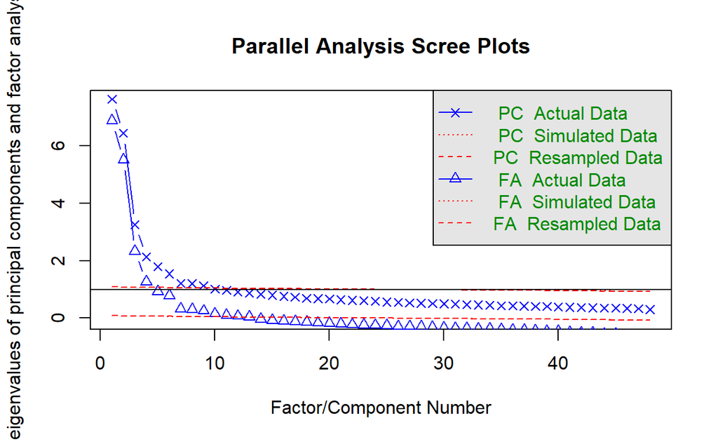

```
Parallel analysis suggests that the number of factors =  13  and the number of components =  9
```

```r
pcaVars %>%
  select(-effect) %>%
  psych::fa.parallel()
```

```r
pcaResult <- FactoMineR::PCA(pcaVars[, grepl("^lvi", names(pcaVars))], ncp = 9,
                             graph = FALSE)

knitr::kable(pcaResult$eig)
```

|  | eigenvalue | percentage of variance | cumulative percentage of variance |
| --- | --- | --- | --- |
| comp 1 | 7.5462425 | 15.7213385 | 15.72134 |
| comp 2 | 6.3546752 | 13.2389066 | 28.96025 |
| comp 3 | 3.2247513 | 6.7182318 | 35.67848 |
| comp 4 | 2.1240260 | 4.4250541 | 40.10353 |
| comp 5 | 1.7854921 | 3.7197753 | 43.82331 |
| comp 6 | 1.5421867 | 3.2128890 | 47.03620 |
| comp 7 | 1.2144938 | 2.5301954 | 49.56639 |
| comp 8 | 1.1982755 | 2.4964074 | 52.06280 |
| comp 9 | 1.1291201 | 2.3523335 | 54.41513 |
| comp 10 | 1.0161345 | 2.1169469 | 56.53208 |
| comp 11 | 0.9721913 | 2.0253984 | 58.55748 |
| comp 12 | 0.9188017 | 1.9141701 | 60.47165 |
| comp 13 | 0.8696986 | 1.8118721 | 62.28352 |
| comp 14 | 0.8378972 | 1.7456192 | 64.02914 |
| comp 15 | 0.8060349 | 1.6792393 | 65.70838 |
| comp 16 | 0.7658066 | 1.5954303 | 67.30381 |
| comp 17 | 0.7301678 | 1.5211829 | 68.82499 |
| comp 18 | 0.6990904 | 1.4564383 | 70.28143 |
| comp 19 | 0.6862440 | 1.4296750 | 71.71110 |
| comp 20 | 0.6702786 | 1.3964138 | 73.10752 |
| comp 21 | 0.6444435 | 1.3425907 | 74.45011 |
| comp 22 | 0.6258091 | 1.3037689 | 75.75388 |
| comp 23 | 0.6186415 | 1.2888364 | 77.04271 |
| comp 24 | 0.5956358 | 1.2409080 | 78.28362 |
| comp 25 | 0.5678216 | 1.1829617 | 79.46658 |
| comp 26 | 0.5573459 | 1.1611373 | 80.62772 |
| comp 27 | 0.5366554 | 1.1180321 | 81.74575 |
| comp 28 | 0.5225191 | 1.0885815 | 82.83433 |
| comp 29 | 0.5100044 | 1.0625092 | 83.89684 |
| comp 30 | 0.5087869 | 1.0599728 | 84.95682 |
| comp 31 | 0.4973342 | 1.0361130 | 85.99293 |
| comp 32 | 0.4791362 | 0.9982005 | 86.99113 |
| comp 33 | 0.4673131 | 0.9735689 | 87.96470 |
| comp 34 | 0.4538273 | 0.9454735 | 88.91017 |
| comp 35 | 0.4362451 | 0.9088439 | 89.81902 |
| comp 36 | 0.4309639 | 0.8978415 | 90.71686 |
| comp 37 | 0.4264234 | 0.8883821 | 91.60524 |
| comp 38 | 0.4149962 | 0.8645753 | 92.46982 |
| comp 39 | 0.4131021 | 0.8606294 | 93.33044 |
| comp 40 | 0.3938996 | 0.8206242 | 94.15107 |
| comp 41 | 0.3815322 | 0.7948588 | 94.94593 |
| comp 42 | 0.3745677 | 0.7803494 | 95.72628 |
| comp 43 | 0.3663487 | 0.7632264 | 96.48950 |
| comp 44 | 0.3551928 | 0.7399850 | 97.22949 |
| comp 45 | 0.3482866 | 0.7255971 | 97.95509 |
| comp 46 | 0.3409852 | 0.7103859 | 98.66547 |
| comp 47 | 0.3332972 | 0.6943691 | 99.35984 |
| comp 48 | 0.3072766 | 0.6401595 | 100.00000 |

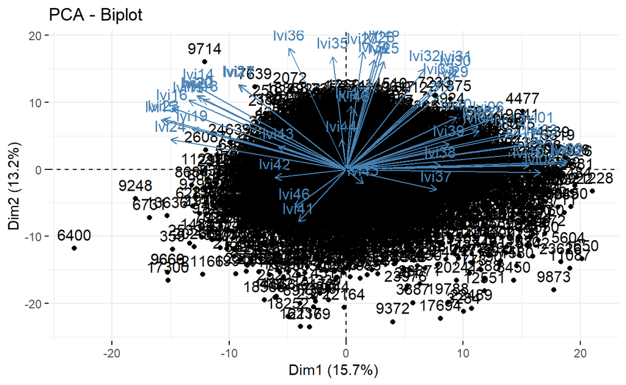

```r
factoextra::fviz_pca(pcaResult)
```

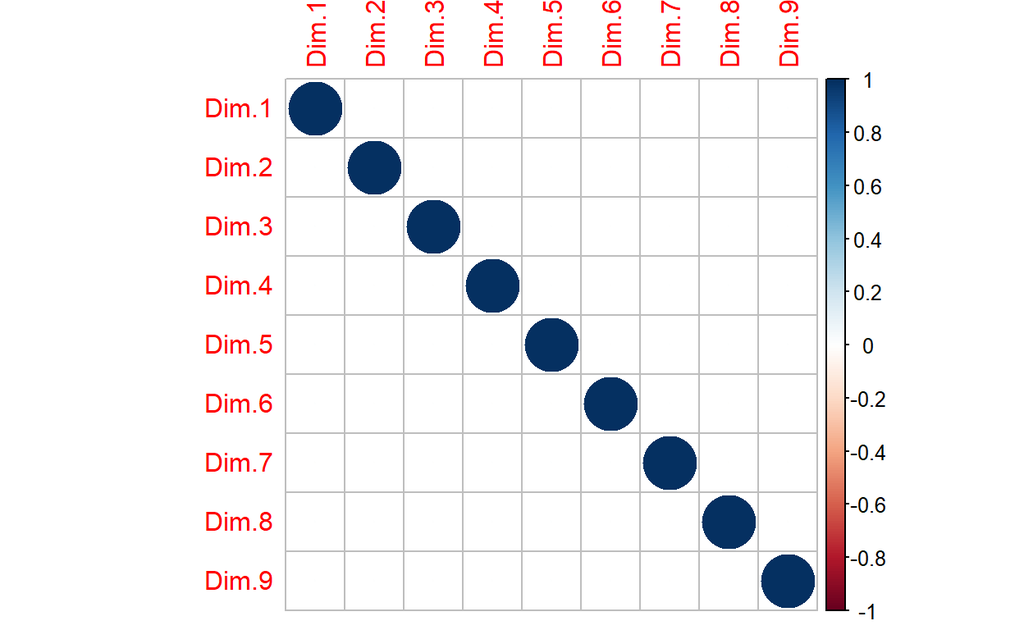

```r
corrplot::corrplot(cor(pcaResult$ind$coord))
```

```r
summary(lm(pcaVars$effect ~ pcaResult$ind$coord))
```

```
Call:
lm(formula = pcaVars$effect ~ pcaResult$ind$coord)

Residuals:
    Min      1Q  Median      3Q     Max
-9.2810 -0.5233  0.1747  0.7076  8.1023

Coefficients:
                          Estimate Std. Error  t value Pr(>|t|)
(Intercept)               8.152211   0.006774 1203.482  < 2e-16 ***
pcaResult$ind$coordDim.1 -0.068471   0.002466  -27.767  < 2e-16 ***
pcaResult$ind$coordDim.2  0.251418   0.002687   93.555  < 2e-16 ***
pcaResult$ind$coordDim.3  0.101923   0.003772   27.019  < 2e-16 ***
pcaResult$ind$coordDim.4 -0.020767   0.004649   -4.467 7.96e-06 ***
pcaResult$ind$coordDim.5 -0.002120   0.005069   -0.418   0.6758
pcaResult$ind$coordDim.6  0.032814   0.005455    6.016 1.81e-09 ***
pcaResult$ind$coordDim.7 -0.109423   0.006147  -17.802  < 2e-16 ***
pcaResult$ind$coordDim.8 -0.010958   0.006188   -1.771   0.0766 .
pcaResult$ind$coordDim.9 -0.125737   0.006375  -19.725  < 2e-16 ***
---
Signif. codes:  0 '***' 0.001 '**' 0.01 '*' 0.05 '.' 0.1 ' ' 1

Residual standard error: 1.099 on 26315 degrees of freedom
  (2 observations deleted due to missingness)
Multiple R-squared:  0.2952,    Adjusted R-squared:  0.2949
F-statistic:  1224 on 9 and 26315 DF,  p-value: < 2.2e-16
```

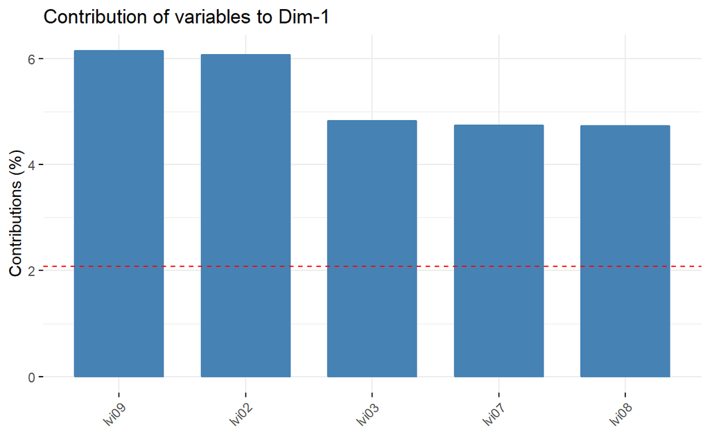

```r
factoextra::fviz_contrib(pcaResult, choice = "var", axes = 1, top = 5)
```

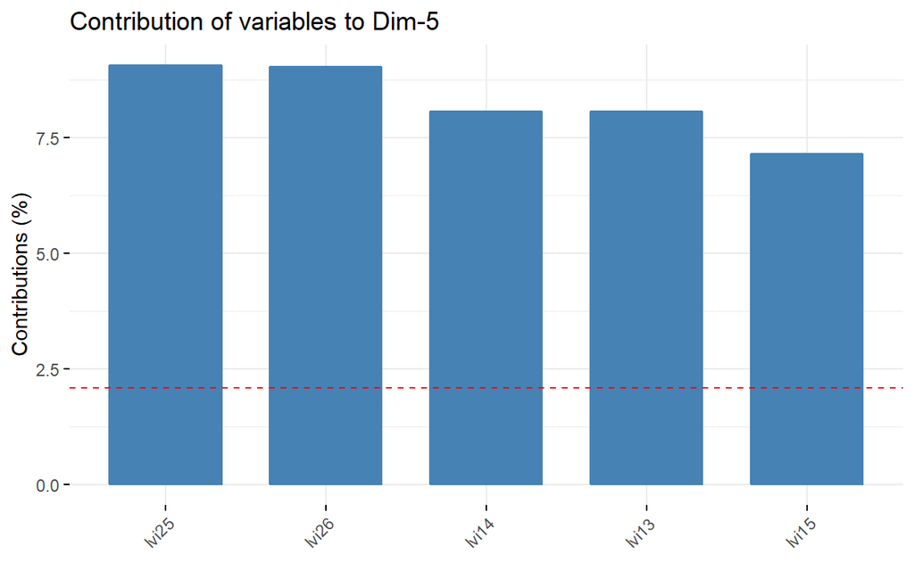

```r
factoextra::fviz_contrib(pcaResult, choice = "var", axes = 5, top = 5)
```

# Regularization

## Ridge

In Ridge regression (or the $\lambda2$ quadratic penalty or L2 regularization) we are applying a penalty to the coefficients of our model. Specifically, we are applying the penalty to the square of the coefficients – this offers a higher penalty for larger coefficients. Ridge regression tends to shrink *everything* down. Why in the world is this a good idea!?! When we are dealing with models, we can often run into issues with over-fitting. When we have over-fitting, we are obtaining near perfect prediction. Great, right? It is great for our current sample, but what if we want to use our model to predict new data? I can tell you…it will probably not perform well. To keep all of the variables in the model and avoid over-fitting, the ridge regression shrinks the coefficients down pretty close to zero. It will also help limit the effects of multicollinearity on a model.

There are several packages that would allow us to do what we need to do. We are going to use the “penalized” package for now, because it gives us the formula interface with which we have practiced. Do know, though, that the glmnet package is the best one to use.

```r
library(penalized)

execPay <- data.table::fread("http://www3.nd.edu/~sberry5/class/anncomp.csv")

execPayShort = execPay %>%
  dplyr::select(SALARY, AGE, OTHCOMP, BONUS, TOTAL_CURR) %>%
  na.omit()

slimTest <- lm(SALARY ~ AGE + OTHCOMP + BONUS + TOTAL_CURR,
              data = execPayShort)

coefficients(slimTest)
```

```
  (Intercept)           AGE       OTHCOMP         BONUS    TOTAL_CURR
 1.270809e-11  2.801225e-13 -1.544796e-15 -1.000000e+00  1.000000e+00
```

```r
ridgeTest <- penalized(response = SALARY, penalized = ~ AGE + OTHCOMP + BONUS + TOTAL_CURR,
                      data = execPayShort, lambda2 = 1,
                      model = "linear", trace = FALSE)

coefficients(ridgeTest)
```

```
  (Intercept)           AGE       OTHCOMP         BONUS    TOTAL_CURR
-5.382333e-09  1.303711e-09  3.702897e-12 -1.000000e+00  1.000000e+00
```

## LASSO

LASSO regression (least absolute shrinkage and selection operator; L1 Absolute Value Penalty) is operating on the same concept as the ridge regression (penalization), but it is doing something a little bit different. LASSO is trying to minimize the sum of the absolute values of the coefficients. Instead of shrinking everything way down, but never to zero, it will shrink some variables down to zero while only moderately shrinking others (if any at all). What does shrinking a coefficient down to zero do? If you said, “it effectively removes it from the model”, then you would be correct. This can provide a hint towards feature selection that we would not have otherwise had.

```r
lassoTest <- penalized(response = SALARY, penalized = ~ AGE + OTHCOMP + BONUS + TOTAL_CURR,
                      data = execPayShort, lambda1 = 1,
                      model = "linear", trace = FALSE)

coefficients(lassoTest)
```

```
  (Intercept)         BONUS    TOTAL_CURR
 5.977284e-08 -1.000000e+00  1.000000e+00
```

## Elastic Net

We have ridge regression and we have LASSO regression – do we need anything else? Probably not, but statisticians get bored. The elastic net is just a combination of the ridge and LASSO. We can do the ridge regularization to shrink coefficients and then do the LASSO to “eliminate” some of the coefficients. In situations with high multicollinearity, LASSO picks one without any real thought.

```r
netTest <- penalized(response = SALARY, penalized = ~ AGE + OTHCOMP + BONUS + TOTAL_CURR,
                      data = execPayShort, lambda1 = 1, lambda2 = 1,
                      model = "linear", trace = FALSE)

coefficients(netTest)
```

```
  (Intercept)       OTHCOMP         BONUS    TOTAL_CURR
 1.195430e-07  6.034634e-13 -1.000000e+00  1.000000e+00
```

### Testing Methods

```r
library(caret)

pcaVars <- na.omit(pcaVars)

trainIndex <- createDataPartition(pcaVars$effect, p = .8, list = FALSE, times = 1)

train <- pcaVars[trainIndex, ]

test <- pcaVars[-trainIndex, ]

regularizedGrid <- expand.grid(lambda1 = seq(1, 3, by = 1), lambda2 = seq(1, 3, by = 1))

regularizedTrain <- caret::train(effect ~ ., data = pcaVars, method = "penalized",
                                 tuneGrid = regularizedGrid, trace = FALSE)

regularizedTrain
```

```
Penalized Linear Regression

20419 samples
   48 predictor

No pre-processing
Resampling: Bootstrapped (25 reps)
Summary of sample sizes: 20419, 20419, 20419, 20419, 20419, 20419, ...
Resampling results across tuning parameters:

  lambda1  lambda2  RMSE      Rsquared   MAE
  1        1        1.058176  0.3199032  0.7922718
  1        2        1.058176  0.3199040  0.7922713
  1        3        1.058175  0.3199049  0.7922707
  2        1        1.058167  0.3199120  0.7922654
  2        2        1.058166  0.3199129  0.7922648
  2        3        1.058165  0.3199137  0.7922643
  3        1        1.058157  0.3199207  0.7922590
  3        2        1.058156  0.3199215  0.7922585
  3        3        1.058155  0.3199223  0.7922579

RMSE was used to select the optimal model using the smallest value.
The final values used for the model were lambda1 = 3 and lambda2 = 3.
```

```r
predictions <- predict(regularizedTrain, newdata = test)

RMSE(predictions, pcaVars$effect)
```

```
[1] 1.48358
```

```r
lmTrain <- lm(effect ~ . , data = pcaVars)

lmPredict <- predict(lmTrain, newdata = test)

RMSE(lmPredict, pcaVars$effect)
```

```
[1] 1.483866
```